# Pruebas Estadisticas

Walter Chanava

30/9/2020

# 1 Introduccion

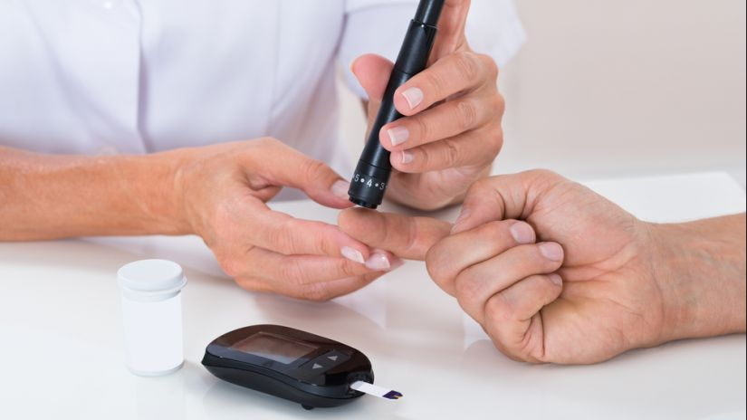

En un hospital universitario del pais se esta realizando un estudio para **conocer si la tolerancia de glucosa en sujetos sanos tiende a decrecer con la edad**. Para ellos se realizo un test oral de glucosa a dos muestras de pacientes sanos, unos jovenes y otros adultos. El test consistio en medir el nivel de glucosa en sangre en el momento de la ingestion (nivel basal) de 100 grs de glucosa y a los 60 minutos de la toma.

# 2 Paquetes

```r
library(readr)
library(dplyr)
library(rstatix)
library(ggpubr)
```

- readr: para leer archivos csv en R.
- dplyr: para manipular los datos en forma de tablas.
- rstatix: trae pruebas inferenciales.
- ggpubr: para graficar boxplots.

# 3 Datos

```r
basal <- read_csv("../Data/control-basal.csv")
basal
```

| Sexo | Tipo | Edad | Valor |
| --- | --- | --- | --- |
| Hombre | Previo | Joven | 90 |
| Mujer | Previo | Joven | 82 |
| Hombre | Previo | Joven | 80 |
| Hombre | Previo | Joven | 75 |
| Hombre | Previo | Joven | 74 |
| Hombre | Previo | Joven | 97 |
| Mujer | Previo | Joven | 76 |
| Mujer | Previo | Joven | 89 |
| Hombre | Previo | Joven | 83 |
| Hombre | Previo | Joven | 77 |

[output cut: 470 more lines]

# 4 EDA

```r
basal %>%
  group_by(Edad) %>%
  get_summary_stats()
```

| Edad | variable | n | min | max | median | q1 | q3 | iqr | mad | mean | sd | se | ci |
| --- | --- | --- | --- | --- | --- | --- | --- | --- | --- | --- | --- | --- | --- |
| Adulto | Valor | 240 | 59 | 273 | 129 | 90.75 | 185.25 | 94.50 | 65.234 | 137.329 | 52.985 | 3.420 | 6.738 |
| Joven | Valor | 240 | 56 | 208 | 110 | 83.00 | 147.25 | 64.25 | 45.961 | 115.571 | 37.279 | 2.406 | 4.740 |

## 4.1 Prueba t para la media de Valor

```r
t1 <- basal %>%
  t_test(Valor ~ 1)
t1
```

|  | .y. | group1 | group2 | n | statistic | df | p |
| --- | --- | --- | --- | --- | --- | --- | --- |
| 1 | Valor | 1 | null model | 480 | 58.89387 | 479 | 1.63e-221 |

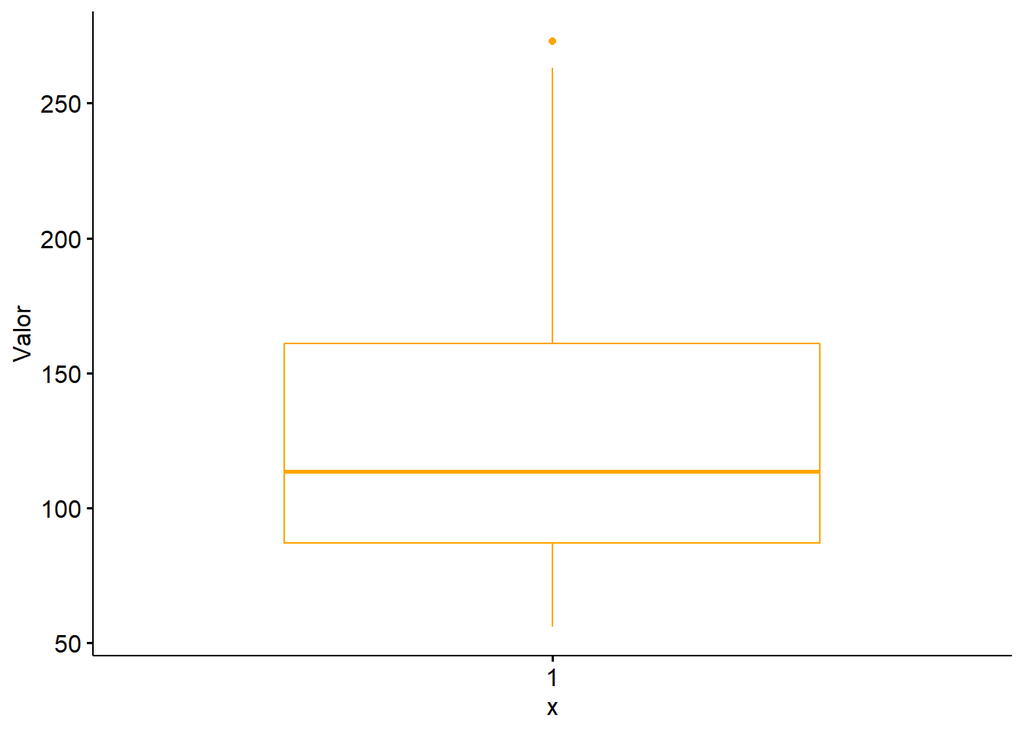

```r
ggboxplot(data = basal, y = "Valor", color = "orange")
```

Como el valor *p* de la prueba t es menor que 0.05, se rechaza $H_0:\mu=0$. Es decir, la media de **Valor** es diferente de 0.

```r
t2 <- basal %>%
  t_test(Valor ~ Sexo)
t2
```

|  | .y. | group1 | group2 | n1 | n2 | statistic | df | p |
| --- | --- | --- | --- | --- | --- | --- | --- | --- |
| 1 | Valor | Hombre | Mujer | 278 | 202 | 2.147068 | 438.1703 | 0.0323 |

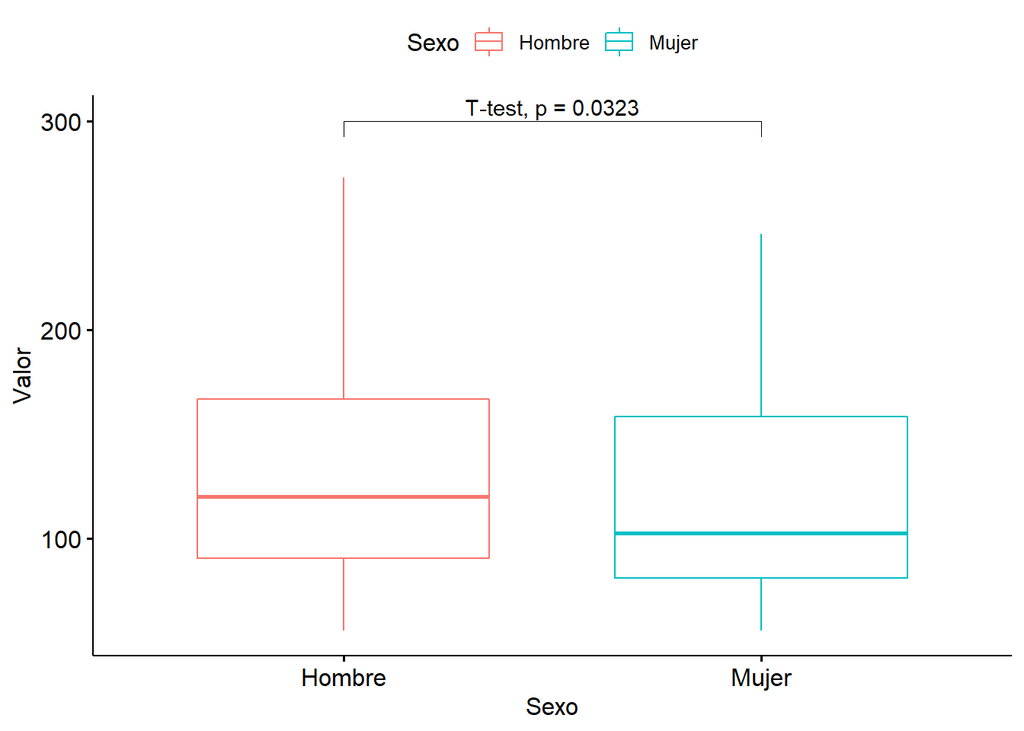

```r
ggboxplot(data = basal, x = "Sexo", y = "Valor", color = "Sexo") +
  stat_pvalue_manual(data = t2, label = "T-test, p = {p}", y.position = 300)
```

Se rechaza $H0:\mu_1=\mu_2$ . Las medias de los grupos de hombres y mujeres son diferentes.

```r
basal %>%
  filter(Edad == "Joven") %>%
  t_test(Valor ~ Sexo)
```

|  | .y. | group1 | group2 | n1 | n2 | statistic | df | p |
| --- | --- | --- | --- | --- | --- | --- | --- | --- |
| 1 | Valor | Hombre | Mujer | 139 | 101 | 1.470004 | 212.6712 | 0.143 |

En este caso se acepta la hipotesis $H_0:\mu_1=\mu_2$ porque el valor *p* es mayor que 0.05.

```r
basal %>%
  t_test(Valor ~ Tipo, paired = TRUE)
```

|  | .y. | group1 | group2 | n1 | n2 | statistic | df | p |
| --- | --- | --- | --- | --- | --- | --- | --- | --- |
| 1 | Valor | Post60 | Previo | 240 | 240 | 56.43269 | 239 | 3.76e-140 |

- Tomar en cuenta si los datos son pareados para agregar el argumento `paired = TRUE`.

```r
basal %>%
  filter(Edad == "Joven") %>%
  group_by(Tipo) %>%
  get_summary_stats()
```

| Tipo | variable | n | min | max | median | q1 | q3 | iqr | mad | mean | sd | se | ci |
| --- | --- | --- | --- | --- | --- | --- | --- | --- | --- | --- | --- | --- | --- |
| Post60 | Valor | 120 | 97 | 208 | 147.5 | 131.5 | 161.25 | 29.75 | 22.239 | 147.608 | 22.771 | 2.079 | 4.116 |
| Previo | Valor | 120 | 56 | 124 | 83.0 | 74.0 | 93.00 | 19.00 | 14.826 | 83.533 | 14.232 | 1.299 | 2.573 |

```r
basal %>%
  group_by(Edad) %>%
  t_test(Valor ~ Tipo, paired = TRUE)
```

|  | Edad | .y. | group1 | group2 | n1 | n2 | statistic | df | p |
| --- | --- | --- | --- | --- | --- | --- | --- | --- | --- |
| 1 | Adulto | Valor | Post60 | Previo | 120 | 120 | 55.98944 | 119 | 2.39e-87 |
| 2 | Joven | Valor | Post60 | Previo | 120 | 120 | 58.23058 | 119 | 2.64e-89 |